# Statistical Inference Intro

Kevin Donovan

January 11, 2021

# Introduction

**Previous Sessions**: focused on data management and visualization with coding

**Now**: focus on statistical analysis of data

**Objectives**

- Conceptual understanding of statistics
- Common pitfalls
- Analytic methods
- Method implementation in R

# Populations, Samples, Data Properties

**Common Viewpoint**:

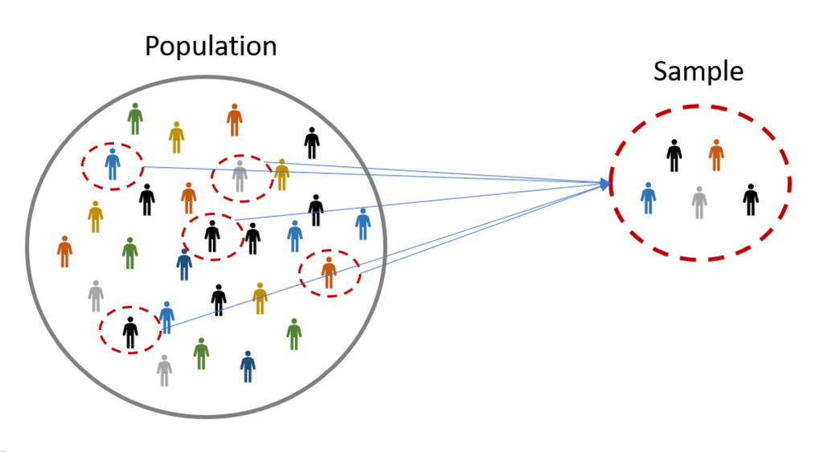

**Limitations**:

- Assumes full information can be obtained
- Assumes randomness ONLY from sampling part of group
- Doesn’t work with many examples of interest (coin tossing)
- Doesn’t allow for large/“infinite” sampling

# Populations, Samples, Data Properties

**Alternative Viewpoint**: Data Generating Mechanism

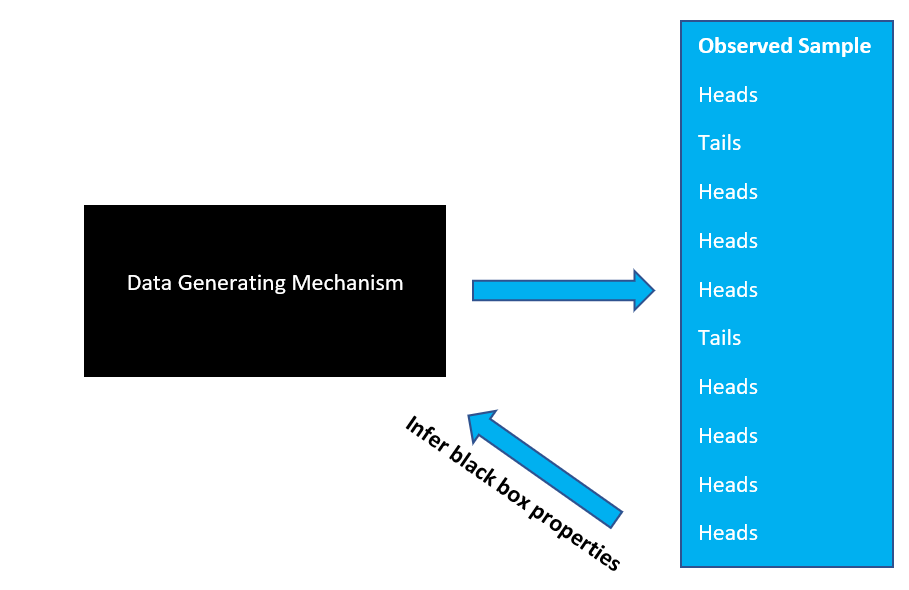

Ex.: What is the **probability** of seeing a heads after flipping coin?

# Populations, Samples, Data Properties

Statistical analysis uses both **inductive** and **deductive** reasoning

[figure not shown]

We **infer** systematic properties and **test** hypotheses based on data

Inferences are **probabilistic** due to unavoidable uncertainty from only seeing output of process

# Parameters and Estimation

**Parameters** = Fixed properties of “black box”

Determine “signal” present in process with random variation being “noise”

**Examples**:

- Variable Distribution
- Mean, Median (“center”)
- Variance, Standard Deviation (“spread”)
- Probability of outcomes

# Parameters and Estimation

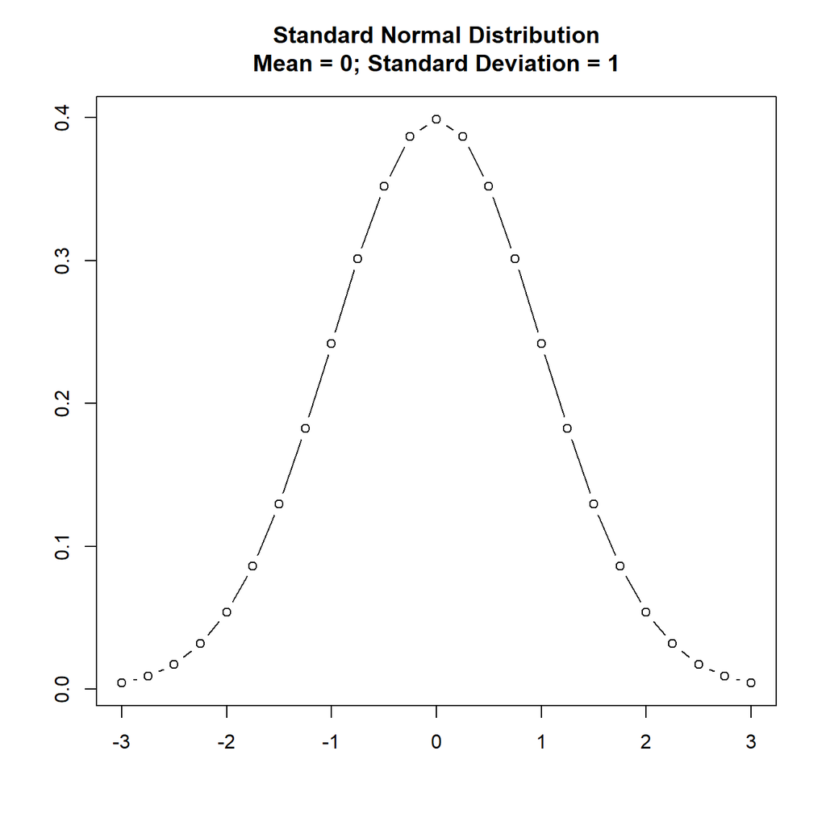

# Parameters and Estimation

**First Step**: Choose parameter(s) we want to estimate

**Second Step**: Determine method for estimation

**Third Step**: Assess estimation

**Concern**: How do we take into account the probabilistic uncertainty?

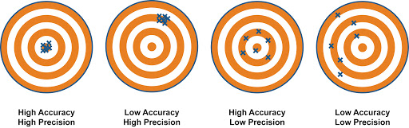

# Parameters and Estimation

**Estimator** = function of observed data

**Sample** = $(X_1, X_2, \ldots, X_n)$ from chosen population

**Exs.**:

Sample Mean = $(X_1 + X_2 + \ldots + X_n)/n = \bar{X}$

Sample Variance = $[(X_1 - \bar{X})^2+(X_2 - \bar{X})^2+ \ldots+(X_n - \bar{X})^2]/n = \hat{\sigma^2}$

# Parameters and Estimation

Estimate will vary from sample to sample. How to measure this variability?

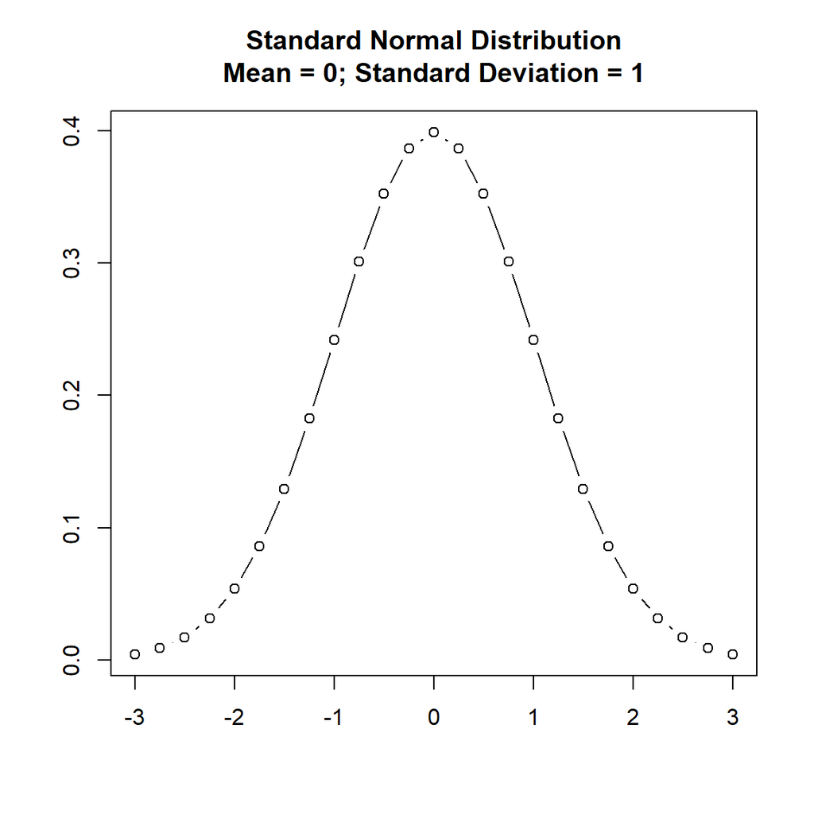

| Sample_Mean | Sample_Variance | n |
| --- | --- | --- |
| 0.1004 | 0.6912 | 50 |
| 0.0691 | 1.2762 | 50 |
| -0.0639 | 0.7917 | 50 |
| 0.2348 | 0.8431 | 50 |
| 0.0649 | 1.1421 | 50 |
| 0.0867 | 1.1022 | 50 |
| 0.2387 | 1.0186 | 50 |
| -0.0602 | 1.0400 | 50 |
| -0.0938 | 0.9676 | 50 |
| -0.3413 | 0.7507 | 50 |

**Answer**: Standard Error and Confidence Intervals

# Parameters and Estimation

**Confidence Interval** = Interval of plausible values for parameter based on sample

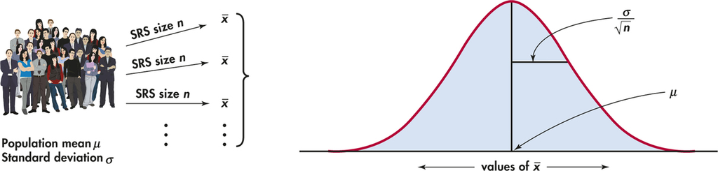

# Parameters and Estimation

**CI Interpretation**: 95% of intervals from sampled data will include true parameter value

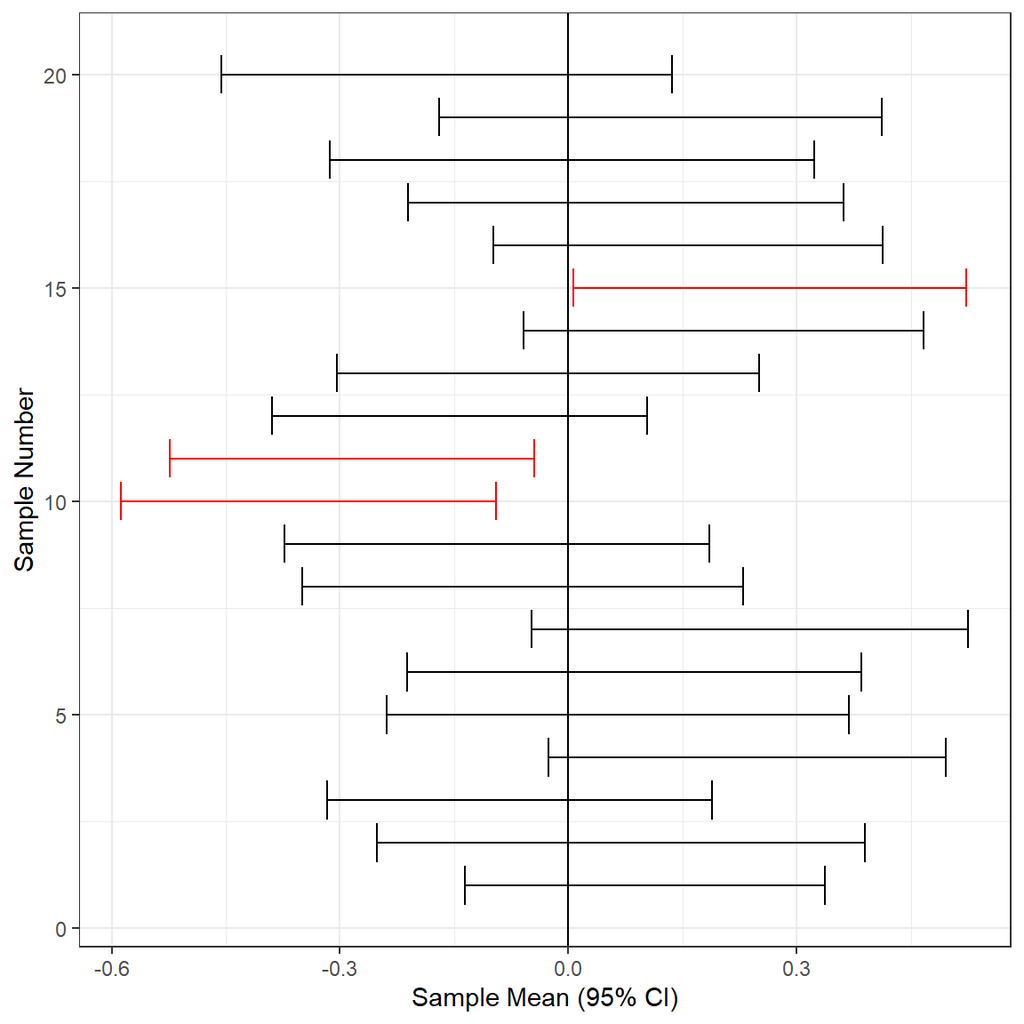

# Hypothesis Testing

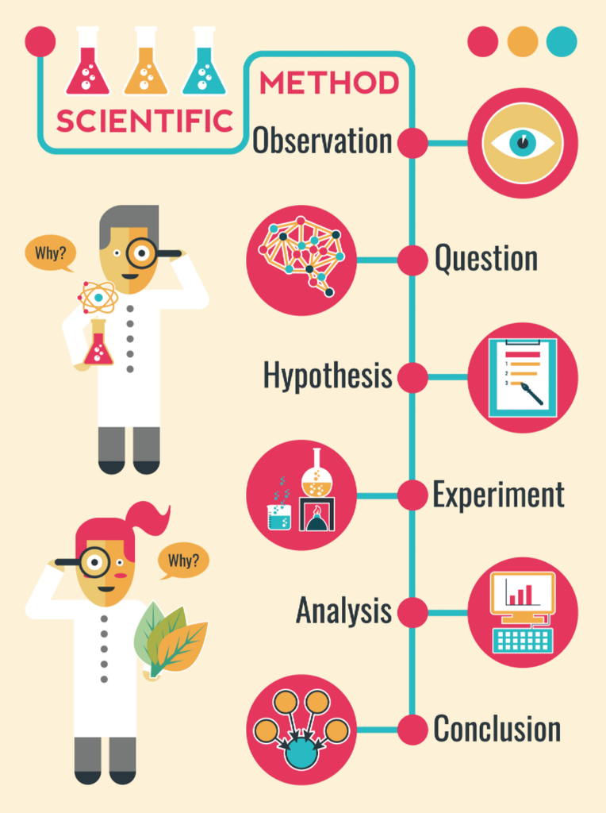

# Hypothesis Testing

**Statistical Analogue**: Hypothesis Testing for parameter(s)

**Example**:

**Scientific Hypothesis**: Infants at 12 months with Autism (ASD) have larger brain volumes then those without ASD

**Statistical Hypothesis**: $\mu_{ASD, 12}>\mu_{ASD_{Neg}, 12}$

where $\mu_{x, 12}=$ mean of total brain volume at 12 months of age for group “x”

# Hypothesis Testing

**For Scientific Testing**: Focused on **falsifying** claim

**For Statistical Testing**: Uncertainty $\implies$ **cannot** “falsify” claim

**instead**

judge evidence to see if one has “enough” to “reject” claim

# Hypothesis Testing

**Process**:

**Step One**: Determine **null** (baseline claim) and **alternative** hypotheses

**Step Two**: Determine quantities used as evidence to make decision (test statistic)

**Step Three**: Evaluate evidence

# Hypothesis Testing

**Evaluating Evidence**:

**Method 1**: Binary decision

- Choose to reject or fail to reject null
- **Do not** “accept” the null or “prove” the null or alternative are true
- **Pro**: Direct conclusion made, may be needed for clinical action
- **Con**: Binary decisions often made using some threshold, reduces info in data

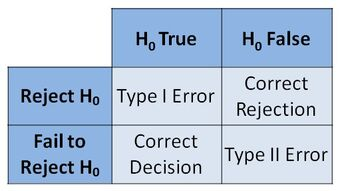

**Method 2**: Continuous evaluation

- **Pro**: More complete reflection of uncertainty in data, thresholds may be arbitrary
- **Con**: Conclusions less decisive, may be diffcult to put results into action

[figure not shown]

# Hypothesis Testing

**Test Statistic**: Function of data used to evaluate null hypothesis claim

**Example**: Recall our standard normal distribution example

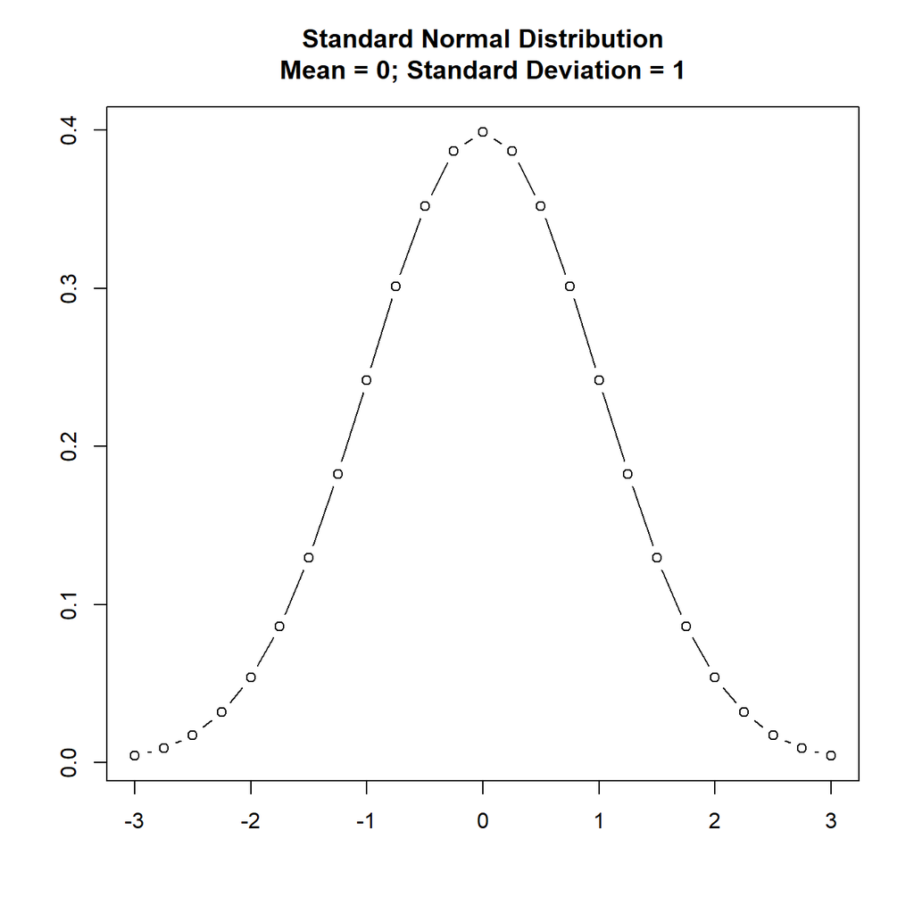

Given this population, suppose we wanted to evaluate the following:

$H_0$ (Null): mean $=0$

$H_1$ (Alt.): mean $\neq 0$

**Idea**: Let’s compare the sample mean from a single sample to 0

**Issue**: How to determine “difference” from 0 given random sampling variability?

**Idea**: Determine distribution of sample mean to determine correspondance with $H_0$

# Hypothesis Testing

**Sample Mean Distribution**: Function of data used to evaluate null hypothesis claim

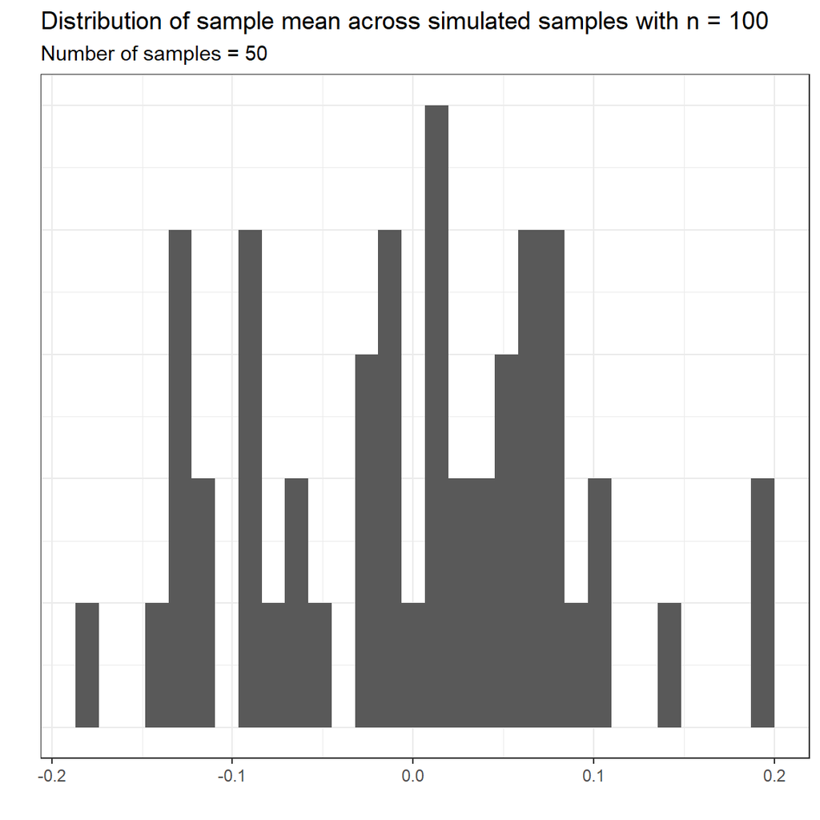

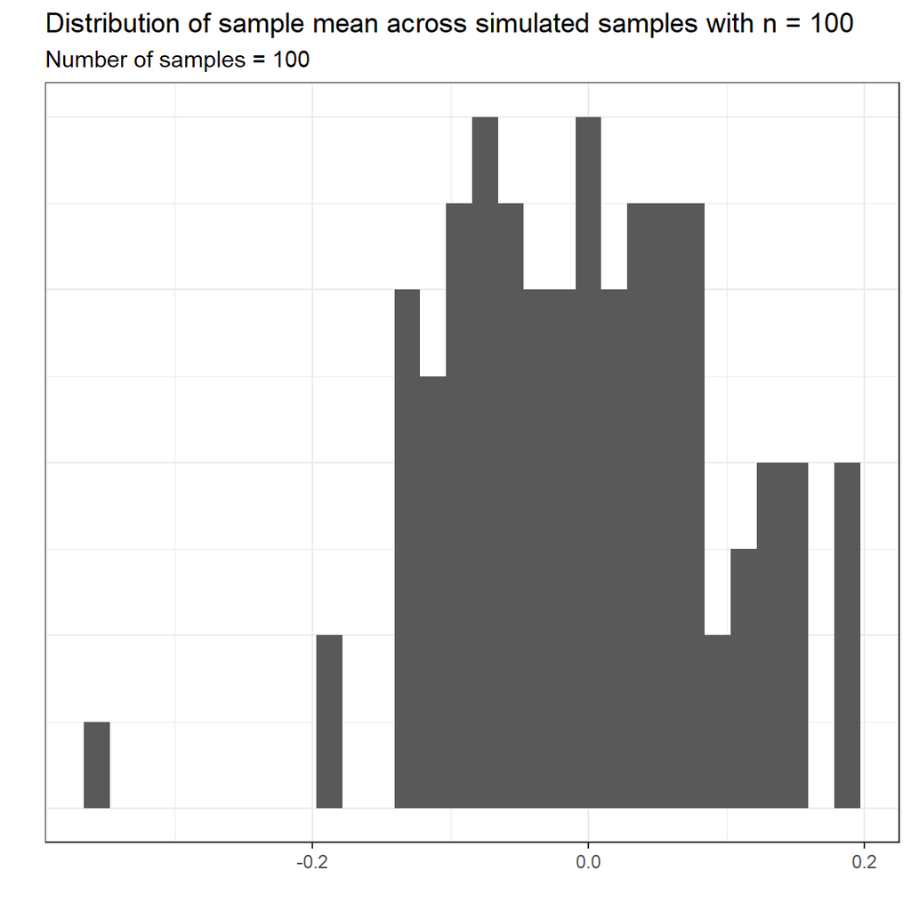

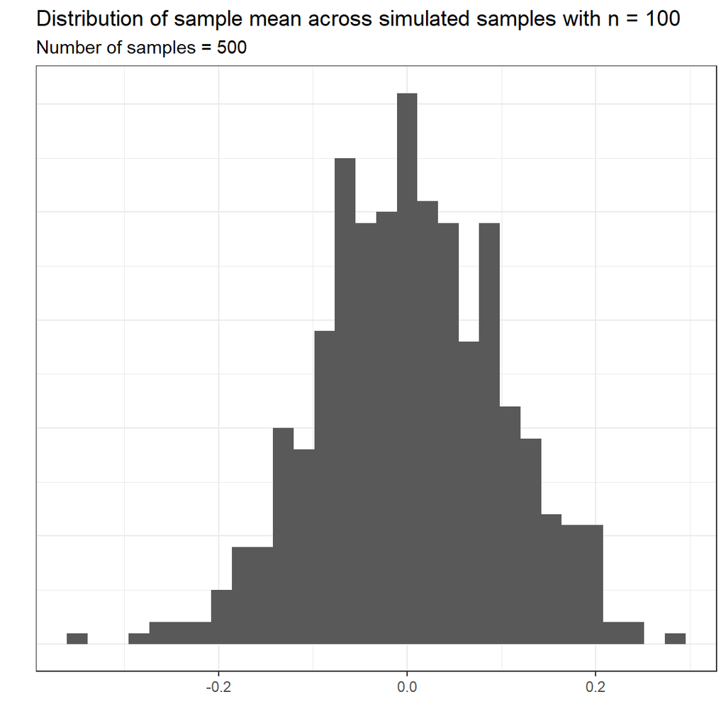

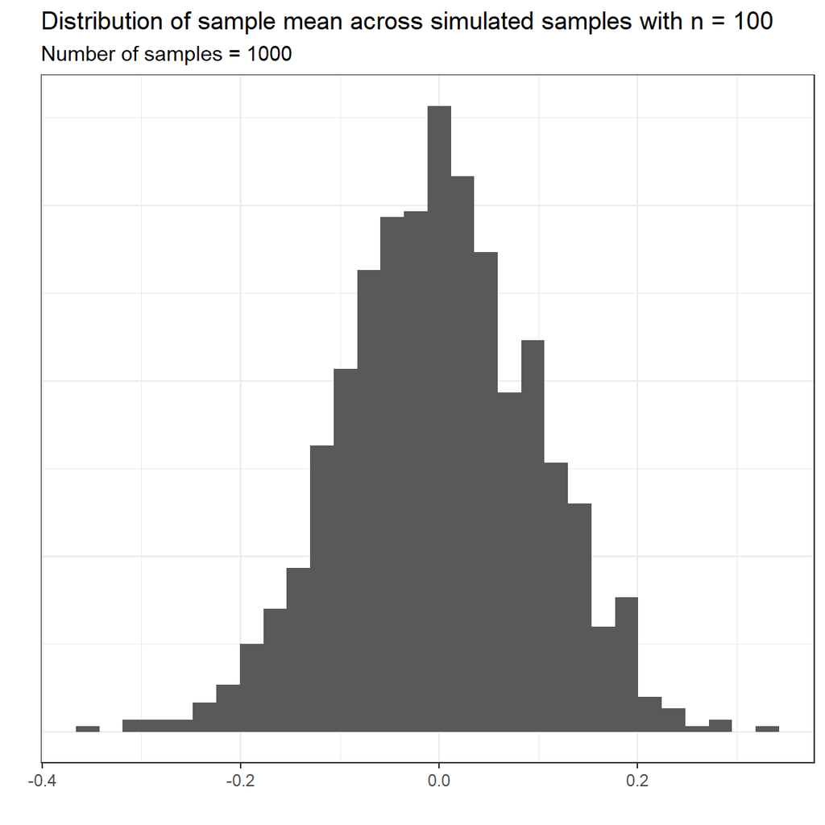

# Hypothesis Testing

**Note**: Need enough samples to accurately estimate distribution (i.e. sample size)

**Observation**: Samples goes up $\implies$ estimated distribution of **sample mean** “converges” to normal curve

Turns out, this is a **mathematical fact** for **any** distribution, with random samples

Referred to as the **Central Limit Theorem (CLT)**

# Hypothesis Testing

**Recall**: Need distribution of sample mean to determine “rare” outcome

**From CLT**, we know

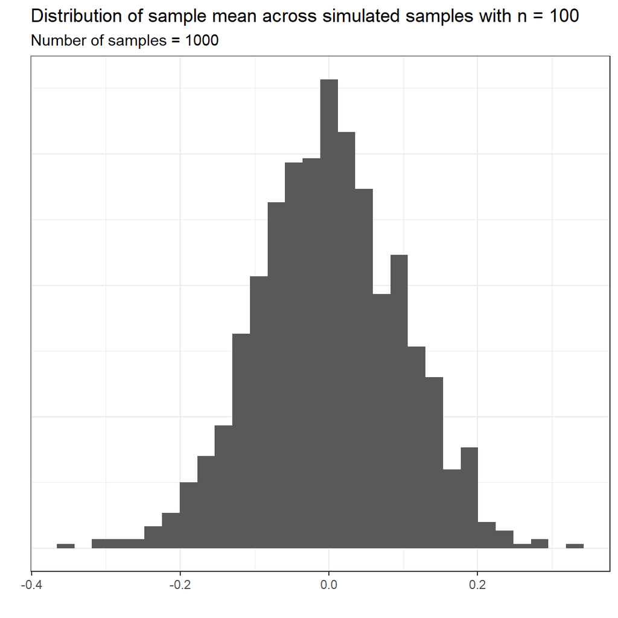

is an accurate estimate of this distribution, **assuming the null hypothesis** of mean = 0

# Hypothesis Testing

Suppose we obtain a sample of size **n=100** and compute the sample mean

Let’s compare this observed sample mean to the expected distribution of values under the null

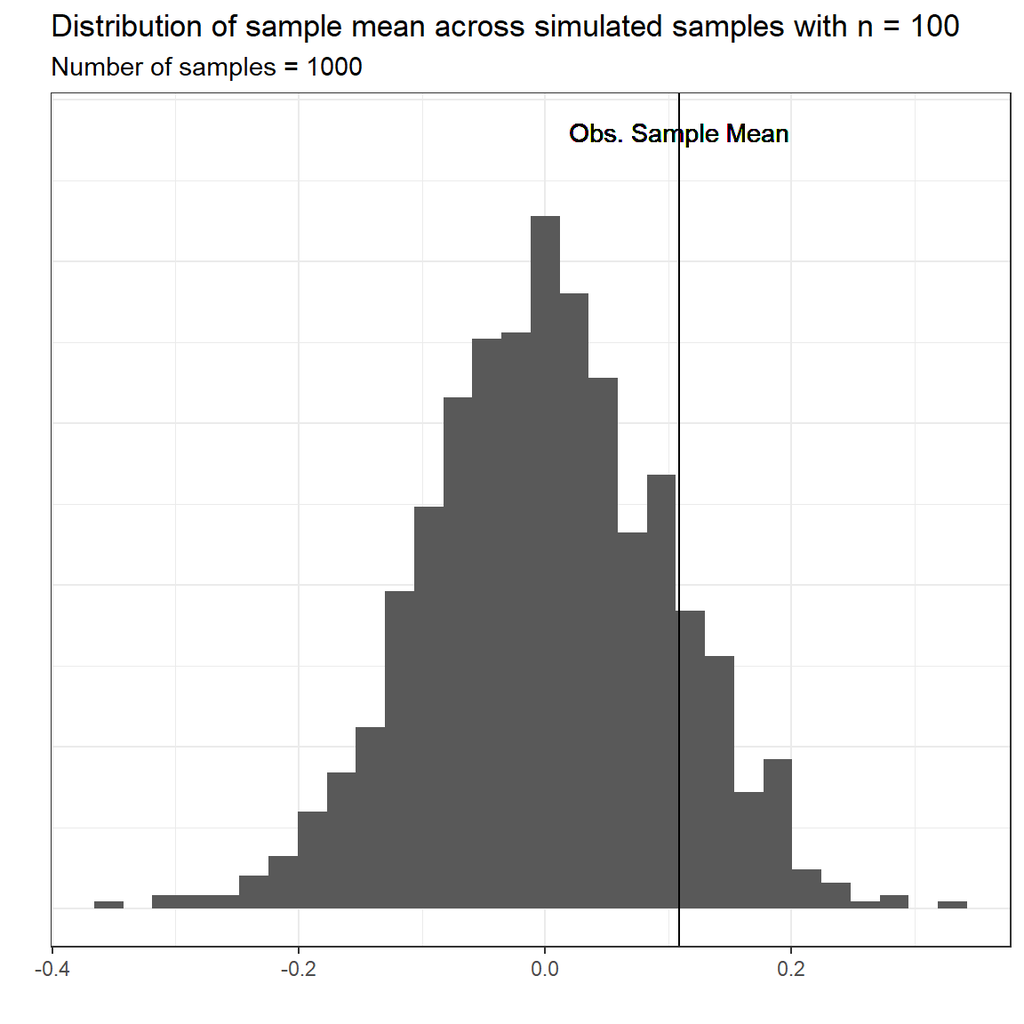

# Hypothesis Testing

Can we quantify this comparison? Yes

1. Compute Test Statistic value = statistic whose distriubtion is known under null

In this case from above, sample mean = one possible test statistic

2. Compute “probability-based” measure = probability of observing sample mean as or extreme then seen in data
- **low** probability = **unlikely** event under null $\implies$ observed sample **poorly matches** with null
- **high** probability = **likely** event under null $\implies$ observed sample **matches** with null

This measure is denoted as a **p-value** = measure of correspondence between sample and null

# Hypothesis Testing

Let’s compute the p-value in the above example

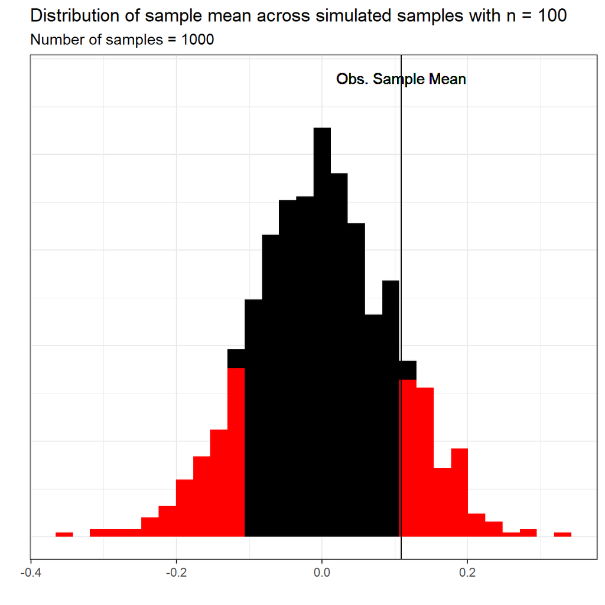

[1] “P-value is 0.276”

Can see much of distribution is shaded in $\implies$ observed sample **not** unusual under null

Note that CTL assumes that the true population standard deviation is **known**

This is rarely the case and often needs to be estimated

This results in the following test statistic:

$T=\frac{\bar{X}-\mu_0}{\hat{\sigma}/\sqrt{n}}$

where $\mu_0$ = mean under $H_0$

which has a **T distribution** with $n-1$ degrees of freedom

# Hypothesis Testing

Finding a test statistic when looking at the mean in this scenario is easy

**However**

n general it can be quite challenging for more complicated scenarios

**Recap**: Testing process

1. Determine parameters of interest
2. Define null and alternative hypotheses
3. Derive test statistic
4. Translate test statistic to more interpretable measure (e.g. p-value)

# Hypothesis Testing

**Complications**:

Many considerations need to be taken into account when testing

1. Multiple testing and **Type I error**
2. **Hypothesis generating** analyses vs **hypothesis testing** analyses
3. [**P-value hacking**](https://journals.plos.org/plosbiology/article?id=10.1371/journal.pbio.1002106#:~:text=Inflation%20bias%2C%20also%20known%20as,results%20%5B12%E2%80%9315%5D) and [**hypothesis generation from data**](https://www2.psych.ubc.ca/~schaller/528Readings/Kerr1998.pdf)

These (and many more) aspects will be covered in future sessions

# Songs of the session

[Mexican Grand Prix by Mogwai](https://www.youtube.com/watch?v=BJZQ9xBrkWo)

[Your Hand in Mine by Explosion in the Sky](https://www.youtube.com/watch?v=cdiY6kijYHE)

[The Big Ship by Brian Eno](https://www.youtube.com/watch?v=lCCJc_V8_MQ)

[figure not shown]

[figure not shown]